# STAT 184 Final Project

Leo Bell

December 11 2020

## call in packages and website information

```r
library(rvest)
library(tidyverse)
library(genius)
library(tidytext)
library(gridExtra)
library(grid)
data("stop_words")
data("sentiments")


webpage <- read_html("https://en.wikipedia.org/wiki/Grammy_Award_for_Record_of_the_Year")
XPATH80s <- '/html/body/div[3]/div[3]/div[5]/div[1]/table[5]'
XPATH90s <- '/html/body/div[3]/div[3]/div[5]/div[1]/table[6]'
XPATH2000s <- '/html/body/div[3]/div[3]/div[5]/div[1]/table[7]'
XPATH2010s <- '/html/body/div[3]/div[3]/div[5]/div[1]/table[8]'
```

## Pull out each decades table, then get what you want from the table.

```r
Table_1980s <-
  webpage %>%
  #read_html() %>%
  html_nodes(xpath = XPATH80s) %>%
  html_table(fill = TRUE)

Table_1980sFixed <- Table_1980s[[1]] %>%
  select(Record, "Artist(s)", "Year[I]") %>%
  rename( "year" = "Year[I]", "track" = "Record", "artist" = "Artist(s)") %>%
  filter(track != " ") %>%
  mutate(decade = "1980s")


Table_1990s <-
  webpage %>%
  #read_html() %>%
  html_nodes(xpath = XPATH90s) %>%
  html_table(fill = TRUE)

Table_1990sFixed <- Table_1990s[[1]] %>%
  select(Record, "Artist(s)", "Year[I]") %>%
  rename( "year" = "Year[I]", "track" = "Record", "artist" = "Artist(s)") %>%
  filter(track != " ") %>%
  mutate(decade = "1990s")


Table_2000s <-
  webpage %>%
  #read_html() %>%
  html_nodes(xpath = XPATH2000s) %>%
  html_table(fill = TRUE)

Table_2000sFixed <- Table_2000s[[1]] %>%
  select(Record, "Artist(s)", "Year[I]") %>%
  rename( "year" = "Year[I]", "track" = "Record", "artist" = "Artist(s)") %>%
  filter(track != " ") %>%
  mutate(decade = "2000s")


Table_2010s <-
  webpage %>%
  #read_html() %>%
  html_nodes(xpath = XPATH2010s) %>%
  html_table(fill = TRUE)

Table_2010sFixed <- Table_2010s[[1]] %>%
  select(Record, "Artist(s)", "Year[I]") %>%
  rename( "year" = "Year[I]", "track" = "Record", "artist" = "Artist(s)") %>%
  filter(track != " ") %>%
  mutate(decade = "2010s")
```

## Join all 4 decades

```r
First <-
  Table_1980sFixed %>%
  full_join(Table_1990sFixed)

Second <-
  First %>%
  full_join(Table_2000sFixed)

AllDecades <-
  Second %>%
  full_join(Table_2010sFixed)
```

## Attach Lyrics to the AllDecades frame

```r
artistlyrics <- AllDecades %>%
  add_genius(artist, track, type = "lyrics")
```

## Get each a word in a song in a year as its own case, and then get split this into each decade, and a “total” frame.

```r
Verse_words <- artistlyrics %>% ### No Removed Words
  unnest_tokens(word, lyric)

Lyrics_all <- Verse_words %>% ## Stop words and the 11 others removed. No decades or years listed
  group_by(decade) %>%
  anti_join(stop_words) %>%
  filter(word != "ba" & word != "du" & word != "yeah" & word != "da" & word != "ya" & word != "ya" & word != "ooh" & word != "gonna" & word != "na" & word != "uh" & word != "la" & word != "hol") %>%
  group_by(word) %>%
  summarise(count = n()) %>%
  arrange(desc(count))




"Lyrics80s" <- Verse_words %>% ## Stop words and the 11 others removed. No years or decades
  anti_join(stop_words) %>%
  filter(word != "ba" & word != "du" & word != "yeah" & word != "da" & word != "ya" & word != "ya" & word != "ooh" & word != "gonna" & word != "na" & word != "uh" & word != "la" & word != "hol") %>%
  filter(decade == "1980s") %>%
  group_by(word) %>%
  summarise(count = n()) %>%
  arrange(desc(count))




"Lyrics90s" <- Verse_words %>% ## Stop words and the 11 others removed No years or decades
  anti_join(stop_words) %>%
  filter(decade == "1990s") %>%
   filter(word != "ba" & word != "du" & word != "yeah" & word != "da" & word != "ya" & word != "ya" & word != "ooh" & word != "gonna" & word != "na" & word != "uh" & word != "la" & word != "hol") %>%
  group_by(word) %>%
  summarise(count = n())  %>%
  arrange(desc(count))


"Lyrics2000s" <- Verse_words %>% ## Stop words and the 11 others removed No years or decades
  anti_join(stop_words) %>%
  filter(decade == "2000s") %>%
   filter(word != "ba" & word != "du" & word != "yeah" & word != "da" & word != "ya" & word != "ya" & word != "ooh" & word != "gonna" & word != "na" & word != "uh" & word != "la" & word != "hol") %>%
  group_by(word) %>%
  summarise(count = n())  %>%
  arrange(desc(count))

"Lyrics2010s" <- Verse_words %>% ## Stop words and the 11 others removed
  anti_join(stop_words) %>%
  filter(decade == "2010s") %>%
   filter(word != "ba" & word != "du" & word != "yeah" & word != "da" & word != "ya" & word != "ya" & word != "ooh" & word != "gonna" & word != "na" & word != "uh" & word != "la" & word != "hol") %>%
  group_by(word) %>%
  summarise(count = n())  %>%
  arrange(desc(count))
```

To begin creating the data frame that will eventually have stop words filtered out. To Begin, I entered the data “stop_words” from tidytext as a dataframe to be able to use later. Next, I used read_html to get the webpage which contains the grammy data I want to scrape. Then I defined XPATH for each decade to map to the part of the page that contains that decades Grammy winners, using the inspect element function in my browser. Then, for each decade, I created a “fixed” and “nonfixed” data frame. The fixed data frames being in a form such that I can use it to attach to other data frames (namely each other, and antijoin with the stop words). For each decade, I used functions such as filter() to remove empty cases, mutate(decade = "___“) for each decade to create a”decade" variable, and rename() to rename some of the more cumbersome names of variables. I now have a data frame where each case is a song that won a grammy, with variables “artist”, “year”, and “decade”. You will notice that the years have a footnote, i.e “1980[44]” I deal with this later when I make the chart that wants years marked. I do not deal with it at this point in the project.

The Next thing I need to do is to join all of these “Table_XXXFixed” tables to get one large table for ALL songs since 1980. I use a “full_join” (I use full_join because I want all cases from both dataframes) joining first the 1980’s table with the 1990’s table, which I call “First”. I then join “First” (80s and 90s) with “Table_2000sFixed”, to make “Second”. I then join this “Second” (80s, 90s, 2000s) with “Table_2010sFixed”, to make a table “AllDecades” which contains each song from 1980 to 2019 as a case.

My next step was to attach the lyrics to the songs in the “AllDecades” data frame. To do this I use the add_genius() function from the “genius” package. This takes a little bit, as it has a lot of words to add. Next, I choose to use unnest_tokens(word, lyric) to get each word in a song as a case, as this allows me to better analze the data, and puts the data in a tidy form for the purposes of this project. I call the new frame created “Verse_words” as it contains each word as a case.

Now, this data frame is *not* filtered for the stop words, and the 11 words provided, so I must make the data frames with these filtered for all decades, and each individual decade. I do this by using the anti_join(stop_words) to only return cases which DON’T have a match with a stop word, and then I use filter( word = != “ba” & word…) to be able to remove the 11 other words we were requested to remove as well. I do for ALL years (Lyrics_all table), the 80s, (Lyrics80s), the 90s, (Lyrics90s,) et cetera up to Lyrics2010s. Taking a look at Lyrics_all, the none of the stop words, nor the 11 other words show up in the dataframe. The top words are about what I expected.

Now I must start getting the plots ready.

## Get First plot ready.

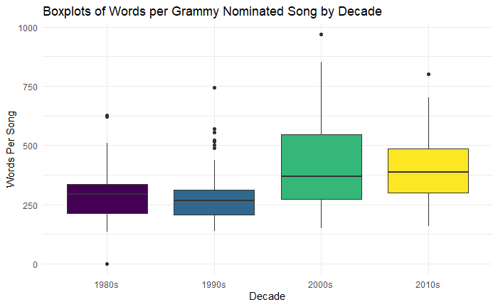

```r
PlotOneFrame <- Verse_words %>% ## Sets up data frame for the first plot.
  group_by(track, decade) %>%
  summarise(total = n()) %>%
  mutate(avg=ifelse(decade=="2010s" , (total)/54, total/50))



ggplot(PlotOneFrame) + #####correct one
 aes(x = decade, y = total, fill = decade) +
 geom_boxplot() +
 scale_fill_viridis_d(option = "viridis") +
 labs(x = "Decade", y = "Words Per Song", title = "Boxplots of Words per Grammy Nominated Song by Decade") +
 theme_minimal() +
 theme(legend.position = "none")
```

Looking at this chart, one thing that I notice is that the 80’s and 90’s generally had less words than the 2000s and 2010s, which isn’t incredibly surprising due to the increase in popularity of very verbose rap in the past 15 years or so. One thing that interests me is that there is a small bundle of points far away from the median in the 1990s. One explanation that I can think of is the beginning popularity of hiphop/rap music in the early to mid 90s, being somewhat of an outlier compared to the more popular genres of grunge (oftentimes less lyrical) and shoegaze (all but instrumental)

## Prepare for second plot, and produce second plot

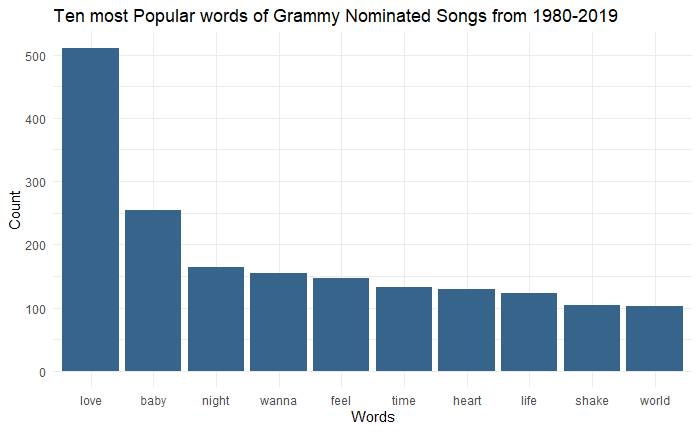

```r
ToptenWordsAllDecades <-Lyrics_all %>% ### Filter out
  filter(word != "ba" & word != "du" & word != "yeah" & word != "da" & word != "ya" & word != "ya" & word != "ooh" & word != "gonna" & word != "na" & word != "uh" & word != "la" & word != "hol") %>%
  arrange(desc(count)) %>%
  head(10)


ggplot(ToptenWordsAllDecades) +
 aes(x = reorder(word,  -count), weight = count) +
 geom_bar(fill = "steelblue4") +
 labs(x = "Words", y = "Count", title = "Ten most Popular words of Grammy Nominated Songs from 1980-2019") +
 theme_minimal()
```

Looking at this chart, I notice that the word “love” is *significantly* more popular than any other word, constituting more usage in the 39 years we look at than the second and third words put together. This is not surprising at all, as many popular songs are about love/feelings, as it is a (generally) universal topic

## Set up and plot third graph. I also made it readable. Get top ten words per each decade

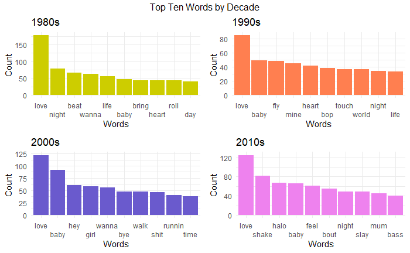

```r
#80s
TopTenEighties <-Lyrics80s %>%
  arrange(desc(count)) %>%
  head(10)


Top1 <- ggplot(TopTenEighties) +
 aes(x = reorder(word, - count), weight = count) +
 geom_bar(fill = "yellow3") +
 labs(x = "Words", y = "Count", title = "1980s") +
 theme_minimal() +
  scale_x_discrete(guide = guide_axis(n.dodge = 2))


#90s
Top90s <-Lyrics90s %>%
  arrange(desc(count)) %>%
  head(10)

Top2 <- ggplot(Top90s) +
 aes(x = reorder(word, - count), weight = count) +
 geom_bar(fill = "coral") +
 labs(x = "Words", y = "Count", title = "1990s") +
 theme_minimal() +
  scale_x_discrete(guide = guide_axis(n.dodge = 2))


#2000s

Top2000s <-Lyrics2000s %>%
  arrange(desc(count)) %>%
  head(10)


Top3 <- ggplot(Top2000s) +
 aes(x = reorder(word, - count), weight = count) +
 geom_bar(fill = "slateblue") +
 labs(x = "Words", y = "Count", title = "2000s") +
 theme_minimal() +
  scale_x_discrete(guide = guide_axis(n.dodge = 2))


#2010s
Top2010s <-Lyrics2010s %>%
  arrange(desc(count)) %>%
  head(10)



top4<- ggplot(Top2010s) +
  aes(x = reorder(word, - count), weight = count) +
  geom_bar(fill = "violet") +
  labs(x = "Words", y = "Count", title = "2010s") +
  theme_minimal() +
  scale_x_discrete(guide = guide_axis(n.dodge = 2))




grid.arrange(Top1, Top2, Top3, top4, nrow = 2, top=textGrob("Top Ten Words by Decade"))
```

Unsuprisingly, Love is the most popular word in every decade by a rather signficant margin, though this appears to be much smaller in the 2000s than the other decades. Something cool you can see with these charts being per decade, is that if a song uses a word a *lot*, for example, “bass”, it shows up in these top words. I suspect in the 2010s that this heavy usage of bass is strongly related to the song “All about That Bass” from 2015.

## Create a numeric equivalent to the “sentiments” dataframe, and then attach to the verse words. Then set up the graph of net sentiment per year.

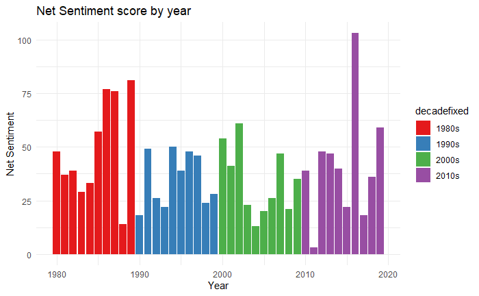

```r
SentimentsNumeric <- sentiments %>%
  mutate(sentiment = ifelse(sentiment == "positive", 1, 0))


"Feelinggsalltime" <-Verse_words %>%
  anti_join(stop_words) %>%
  filter(word != "ba" & word != "du" & word != "yeah" & word != "da" & word != "ya" & word != "ya" & word != "ooh" & word != "gonna" & word != "na" & word != "uh" & word != "la" & word != "hol") %>%
  inner_join(SentimentsNumeric) %>%
  group_by(year) %>%
  summarise(netfeeling = sum(sentiment)) %>%
  mutate(decadefixed=ifelse(grepl("^198",year), "1980s", year)) %>%
  mutate(decadefixed=ifelse(grepl("^199",year), "1990s", decadefixed)) %>%
  mutate(decadefixed=ifelse(grepl("^200",year), "2000s", decadefixed)) %>%
  mutate(decadefixed=ifelse(grepl("^201",year), "2010s", decadefixed))



Feelinggsalltime$year <- substr(Feelinggsalltime$year, 0, 4)

Feelinggsalltime <- Feelinggsalltime %>%
  mutate(year = as.numeric(year))








ggplot(Feelinggsalltime) +
  aes(x = year, weight = netfeeling, fill = decadefixed, ) +
  geom_bar() +
  scale_fill_brewer(palette = "Dark2") +
  scale_color_brewer(palette = "Dark2") +
  labs(x = "Year", y = "Net Sentiment", title = "Net Sentiment score by year ") +
  scale_fill_hue() +
  scale_color_hue() +
  scale_fill_brewer(palette = "Set1") +
  theme_minimal()
```

```r
NA
NA
```

Looking at this chart, I have some questions. In 2011 there is a *huge* dip in the net sentiment, which, looking at the songs that won that year, could make some sense, as two of the songs come from either Eminem (who is known for somewhat shocking music) or Jay Z, a rapper who is not known for his “positive” lyrics. There is also a song called “F*** you” Looking at the lyrics for these songs, this dip is understandable, though still an outlier. There is also a VERY large jump in 2016. Me, being the curious observer I am, decided to check the top songs for that year. One of the top songs is the song “Uptown Funk” which is a very uppbeat song, and a Taylor swift song, which are oftentimes very positive. Again, I can’t explain *why* these songs won in particular years, if it was chance, or something random. Something else interesting is that from the mid 2000’s until 2007 there is a steady climb in the “net sentiment”, until 2008, where it drops significantly. I would suspect that this is at least somewhat related to the subprime mortgage crisis/recession, though I could not make this statement for sure.

## Graph 5. Create a chart of mean sentiment per decade

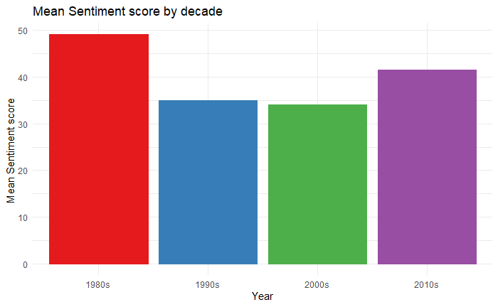

```r
Feelingsbydecade <- Feelinggsalltime %>%
  group_by(decadefixed) %>%
  summarise(avgfeelings = mean(netfeeling))




ggplot(Feelingsbydecade) +
 aes(x = decadefixed, fill = decadefixed, colour = decadefixed, weight = avgfeelings) +
 geom_bar() +
 scale_fill_brewer(palette = "Set1") +
 scale_color_brewer(palette = "Set1") +
 labs(x = "Year", y = "Mean Sentiment score ", title = "Mean Sentiment score by decade") +
 theme_minimal() +
  theme(legend.position = "none")
```

Looking at the chart, I can see that the mean sentiment score dropped in the 90s and 2000s, and then climbed back up in the 2010s. The time frames covered are too big for me to really come up with any conjecture, outside of that the 2010s mean sentiment may be skewed up by that one very high year.

## Plot 6 graphing.

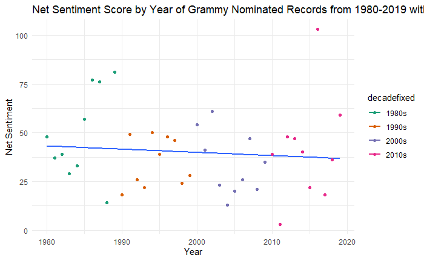

```r
ggplot(Feelinggsalltime) +
  aes(x = year, y = netfeeling, group = 1, fill = decadefixed, colour = decadefixed) +
  geom_smooth(se = FALSE, method = lm) +
  geom_point() +
  scale_fill_brewer(palette = "Dark2") +
 scale_color_brewer(palette = "Dark2") +
  theme_minimal() +
  labs(x = "Year", y = "Net Sentiment", title = "Net Sentiment Score by Year of Grammy Nominated Records from 1980-2019 with Linear Model Fix")
```

```r
NA
```

Looking at this graph, the *linear* (straight line) regression fit “shows” that the net sentiment generally goes down. Looking at the graphic, I would say that there is likely too much error between each year to be able to really make any conclusive statements. I would have to do a t-test to be able to check if the year is a statistically significant determinant of the change in net sentiment.

## Presentation zoom link

https://psu.zoom.us/rec/share/xeyhAKe6X2ZKeR7QbfHDe91DoYAl3aYdh98sumxtMZ6OkZlMzNds3qcs4zB-4Fdb.fCDr4UjnHIAuB6Fp